# BCB420 A1

Fanxing Bu

Feb 4 2020

**Note**: Some codes adapted from the lecture silds written by Ruth Isserlin.

# Launching RStudio in Docker

```
docker run -e PASSWORD=1234 --rm -p 8787:8787 -v /Users/bfx/Documents/BCB420:/home/rstudio/docker_bcb420 risserlin/bcb420-base-image
```

# Find dataset of interest

I used GEOmetadb to find the dataset of interest.

```r
# install GEOmetadb
if (!requireNamespace("BiocManager", quietly = TRUE))
    install.packages("BiocManager")
if (!requireNamespace("GEOmetadb", quietly = TRUE))
    BiocManager::install("GEOmetadb")

library(GEOmetadb)
library(knitr)
library(edgeR)
library(limma)
```

#### Set up GEOmetadb

```r
# get GEO meta data database
if(!file.exists('GEOmetadb.sqlite')) getSQLiteFile()

#Check the version info
file.info('GEOmetadb.sqlite')
```

|  | size | isdir | mode | mtime | ctime | atime | uid | gid | uname | grname |
| --- | --- | --- | --- | --- | --- | --- | --- | --- | --- | --- |
| GEOmetadb.sqlite | 8811945984 | FALSE | 644 | 2020-02-03 23:34:17 | 2020-02-03 23:34:17 | 2020-02-03 23:34:17 | 1000 | 1000 | rstudio | rstudio |

```r
#connect to the GEO meta data database
con <- dbConnect(SQLite(),'GEOmetadb.sqlite')

# check out the tables that are available
geo_tables <- dbListTables(con)
geo_tables
```

```
##  [1] "gds"               "gds_subset"        "geoConvert"
##  [4] "geodb_column_desc" "gpl"               "gse"
##  [7] "gse_gpl"           "gse_gsm"           "gsm"
## [10] "metaInfo"          "sMatrix"
```

#### Looking for the dataset of interest

```r
# create sql query to find the series that
# submission_date later than '2015-01-01'
# title include human and HiSeq
# organism contains Homo sapiens
# to ensure the series are new, RNA-seq, about human
sql <- paste("SELECT DISTINCT gse.title,gse.gse, gpl.title,",
             " gse.submission_date,",
             " gse.supplementary_file",
             "FROM",
             "  gse JOIN gse_gpl ON gse_gpl.gse=gse.gse",
             "  JOIN gpl ON gse_gpl.gpl=gpl.gpl",
             "WHERE",
             "  gse.submission_date > '2015-01-01' AND",
             "  gse.title LIKE '%human%' AND",
             "  gpl.organism LIKE '%Homo sapiens%' AND",
             "  gpl.title LIKE '%HiSeq%' ",
             "  ORDER BY gse.submission_date DESC",sep=" ")

rs <- dbGetQuery(con,sql)

# break the file names up and just get the actual file name
unlist(lapply(rs$supplementary_file,
              FUN = function(x){x <- unlist(strsplit(x,";")) ;
              x <- x[grep(x,pattern="txt",ignore.case = TRUE)];
                tail(unlist(strsplit(x,"/")),n=1)}))[1:10]

# to find the series have processed data in supplementary file.
counts_files <- rs$supplementary_file[grep(rs$supplementary_file,
                              pattern = "count",ignore.case = TRUE)]
```

I choose [GSE111958: Transcriptional profile of human STAT1-/- fibroblasts expressing LY6E or empty control vector](https://www.ncbi.nlm.nih.gov/geo/query/acc.cgi?acc=GSE111958)

#### Download the dataset

```r
sfiles = getGEOSuppFiles('GSE111958')

fnames = rownames(sfiles)

myData = read.delim(fnames[1],header=TRUE)
```

Preview my data, and everything looks good.

```r
head(myData)
```

|  | GENE_NAME | SEU227 | SEU235 | SEU239 | SLU227 | SLU235 | SLU239 |
| --- | --- | --- | --- | --- | --- | --- | --- |
| 1 | OR4F5 | 0.0000000 | 0.000000 | 0.00000000 | 0.000000 | 0.00000000 | 0.00000 |
| 2 | AL627309.1 | 0.0724538 | 0.000000 | 0.03955897 | 0.000000 | 0.07166093 | 0.00000 |
| 3 | OR4F29 | 0.0000000 | 0.000000 | 0.00000000 | 0.000000 | 0.00000000 | 0.00000 |
| 4 | OR4F16 | 0.0000000 | 0.000000 | 0.00000000 | 0.000000 | 0.00000000 | 0.00000 |
| 5 | SAMD11 | 0.4709497 | 0.471399 | 2.61089181 | 0.542199 | 0.25081325 | 1.07234 |
| 6 | NOC2L | 36.4804864 | 28.428988 | 38.92602338 | 28.968916 | 25.51129037 | 26.14859 |

# Processing the data

#### Data Exploration

##### Get Description of my dataset

```r
gse <- getGEO("GSE111958",GSEMatrix=FALSE)
kable(data.frame(head(Meta(gse))), format = "html")
```

| contact_address | contact_city | contact_country | contact_department | contact_email | contact_institute |
| --- | --- | --- | --- | --- | --- |
| 5323 Harry Hines Blvd | Dallas | USA | Department of Microbiology | John.Schoggins@UTSouthwestern.edu | UT Southwester Medical Center |

##### Get Platform information

```r
current_gpl <- names(GPLList(gse))[1]
current_gpl_info <- Meta(getGEO(current_gpl))
```

**Platform title** : Illumina HiSeq 2500 (Homo sapiens)  
**Submission data** : Mar 14 2013  
**Last update data** : Mar 27 2019  
**Organims** : Homo sapiens  
**Number of GEO datasets that use this techology** : 5972  
**Number of GEO samples that use this technology** : 161580

##### Get Expression Data

```r
exp <- read.delim(fnames[1],header=TRUE,
                check.names = FALSE)
```

```r
dim(exp)
```

```
## [1] 19410     7
```

There are 19410 genes measured and 6 samples

```r
samples <- data.frame(lapply(colnames(exp)[2:7],
        FUN=function(x){unlist(strsplit(x, perl=TRUE, "(?=[A-Za-z])(?<=[0-9])|(?=[0-9])(?<=[A-Za-z])"))}))

colnames(samples) <- colnames(exp)[2:7]
rownames(samples) <- c("condition", "cell")
samples <- data.frame(t(samples))
```

Define the groups, The first 3 character represent the conditions (Empty control or LY6E)

#### Mapping to HUGO symbols

The data already has column called GENE_NAME which is HUGO symbols

```r
head(exp$GENE_NAME)
```

```
## [1] OR4F5      AL627309.1 OR4F29     OR4F16     SAMD11     NOC2L
## 19410 Levels: A1BG A1CF A2M A2ML1 A3GALT2 A4GALT A4GNT AAAS AACS ... ZZZ3
```

Then, I used https://www.genenames.org/tools/multi-symbol-checker/ to check the symbols, all mapped.

```r
head(HUGO<-read.table("hgnc-symbol-check.csv", header = TRUE, sep = ","))
```

|  | Input | Match.type | Approved.symbol | Approved.name | HGNC.ID | Location |
| --- | --- | --- | --- | --- | --- | --- |
| 1 | NOC2L | Approved symbol | NOC2L | NOC2 like nucleolar associated transcriptional repressor | HGNC:24517 | 1p36.33 |
| 2 | AGRN | Approved symbol | AGRN | agrin | HGNC:329 | 1p36.33 |
| 3 | C1orf159 | Approved symbol | C1orf159 | chromosome 1 open reading frame 159 | HGNC:26062 | 1p36.33 |
| 4 | SDF4 | Approved symbol | SDF4 | stromal cell derived factor 4 | HGNC:24188 | 1p36.33 |
| 5 | B3GALT6 | Approved symbol | B3GALT6 | beta-1,3-galactosyltransferase 6 | HGNC:17978 | 1p36.33 |
| 6 | UBE2J2 | Approved symbol | UBE2J2 | ubiquitin conjugating enzyme E2 J2 | HGNC:19268 | 1p36.33 |

#### Clean Data

##### Check duplicates

```r
summarized_gene_counts <- sort(table(exp$GENE_NAME),decreasing = TRUE)

# find the gene appeared more than 1
length(summarized_gene_counts[which(summarized_gene_counts>1)])
```

```
## [1] 0
```

There is no duplicates.

```r
# get rid of low counts
keep = rowSums(exp[ ,2:7] > 1) >= 3
exp_filtered = exp[keep,]
```

In edgeR, it is recommended to remove features without at least 1 read per million in n of the samples, where n is the size of the smallest group of replicates. Since the size of my group is 3, I set n=3 here.  
The origin data has 19410 genes, filtered data has 11433 genes, 7977 genes have been deleted.

#### Normalization

##### Preview my data with Boxplot and Density plot

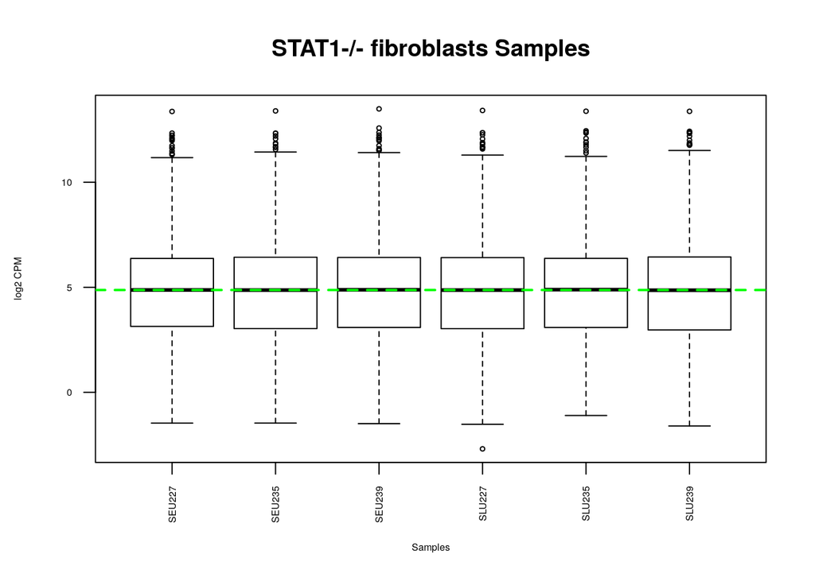

```r
data2plot <- log2(exp_filtered[,2:7])
boxplot(data2plot, xlab = "Samples", ylab = "log2 CPM",
        las = 2, cex = 0.5, cex.lab = 0.5,
        cex.axis = 0.5, main = "STAT1-/- fibroblasts Samples")
#draw the median on each box plot
abline(h = median(apply(data2plot, 2, median)), col = "green", lwd = 2, lty = "dashed")
```

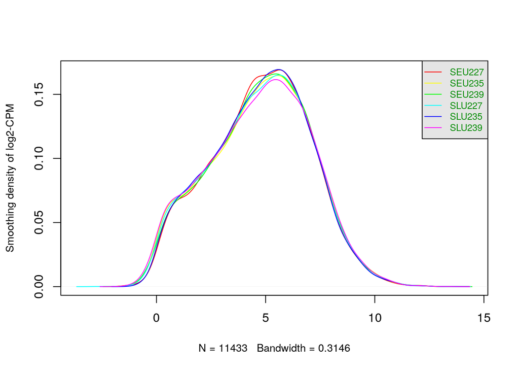

```r
counts_density <- apply(log2(exp_filtered[,2:7]), 2, density)
  #calculate the limits across all the samples
    xlim <- 0; ylim <- 0
    for (i in 1:length(counts_density)) {
      xlim <- range(c(xlim, counts_density[[i]]$x));
      ylim <- range(c(ylim, counts_density[[i]]$y))
    }
    cols <- rainbow(length(counts_density))
    ltys <- rep(1, length(counts_density))

    plot(counts_density[[1]], xlim=xlim, ylim=ylim, type="n",
         ylab="Smoothing density of log2-CPM", main="", cex.lab = 0.85)
    #plot each line
    for (i in 1:length(counts_density)) lines(counts_density[[i]], col=cols[i], lty=ltys[i])
    #create legend
    legend("topright", colnames(data2plot),
           col=cols, lty=ltys, cex=0.75,
           border ="blue",  text.col = "green4",
           merge = TRUE, bg = "gray90")
```

##### Trimmed Mean of M-values

Since my dataset is sample based and used RNA-Seq, I choose Trimmed Mean of M-values (TMM) to normalize the data.

```r
filtered_data_matrix <- as.matrix(exp_filtered[, 2:7])
rownames(filtered_data_matrix) <- exp_filtered$GENE_NAME
d <- DGEList(counts=filtered_data_matrix, group=samples$condition)
d <- calcNormFactors(d)
normalized_counts <- cpm(d)
```

Boxplot: Origin VS Nomalized

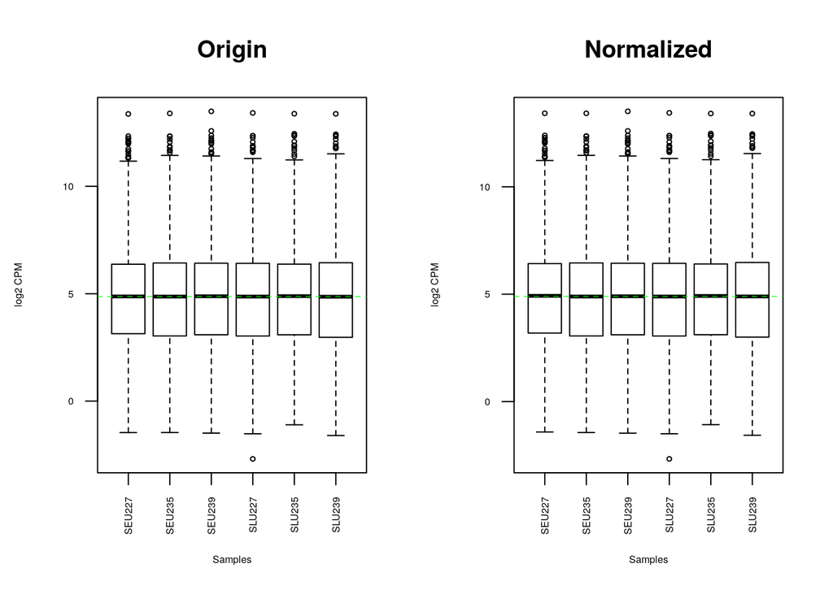

```r
# my data has already cpm-converted,
layout(matrix(c(1, 2), ncol = 2))
# origin
data2plot <- log2(exp_filtered[,2:7])
boxplot(data2plot, xlab = "Samples", ylab = "log2 CPM",
        las = 2, cex = 0.5, cex.lab = 0.5,
        cex.axis = 0.5, main = "Origin")
#draw the median on each box plot
abline(h = median(apply(data2plot, 2, median)), col = "green", lwd = 0.6, lty = "dashed")

# normalized
data2plot <- log2(normalized_counts)
boxplot(data2plot, xlab = "Samples", ylab = "log2 CPM",
        las = 2, cex = 0.5, cex.lab = 0.5,
        cex.axis = 0.5, main = "Normalized")
#draw the median on each box plot
abline(h = median(apply(data2plot, 2, median)), col = "green", lwd = 0.6, lty = "dashed")
```

Density plot: Origin VS Nomalized

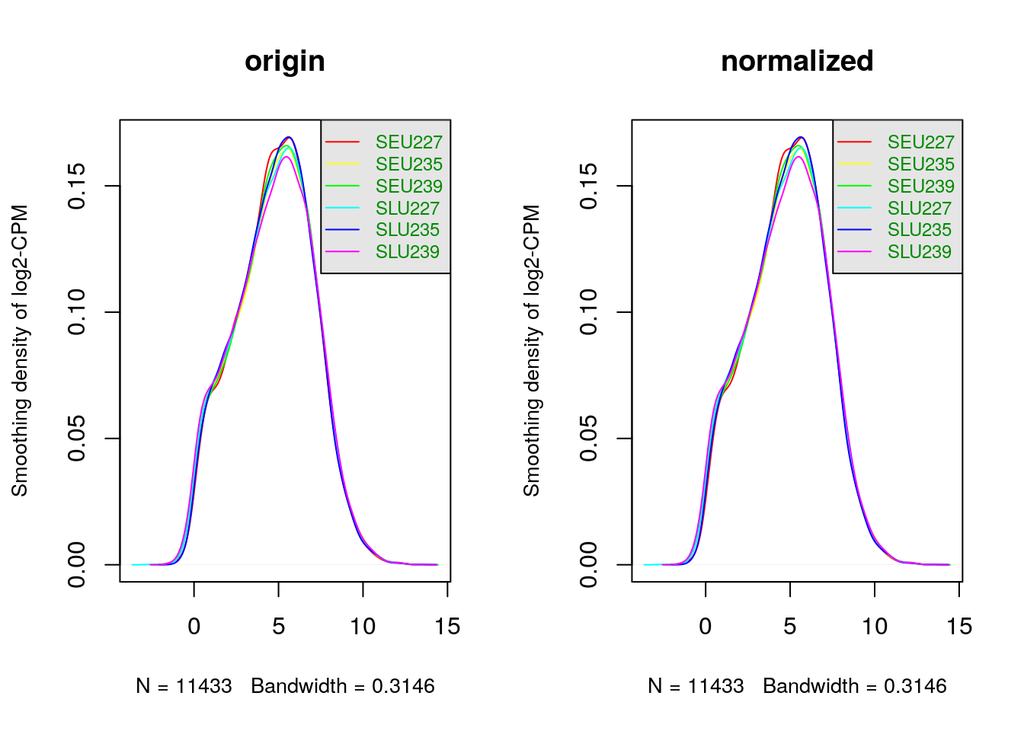

```r
layout(matrix(c(1, 2), ncol = 2))

# origin dataset
counts_density <- apply(log2(exp_filtered[,2:7]), 2, density)
  #calculate the limits across all the samples
    xlim <- 0; ylim <- 0
    for (i in 1:length(counts_density)) {
      xlim <- range(c(xlim, counts_density[[i]]$x));
      ylim <- range(c(ylim, counts_density[[i]]$y))
    }
    cols <- rainbow(length(counts_density))
    ltys <- rep(1, length(counts_density))

    plot(counts_density[[1]], xlim=xlim, ylim=ylim, type="n",
         ylab="Smoothing density of log2-CPM", main="origin", cex.lab = 0.85)
    #plot each line
    for (i in 1:length(counts_density)) lines(counts_density[[i]], col=cols[i], lty=ltys[i])
    #create legend
    legend("topright", colnames(data2plot),
           col=cols, lty=ltys, cex=0.75,
           border ="blue",  text.col = "green4",
           merge = TRUE, bg = "gray90")

# normalized
counts_density <- apply(log2(normalized_counts), 2, density)
  #calculate the limits across all the samples
    xlim <- 0; ylim <- 0
    for (i in 1:length(counts_density)) {
      xlim <- range(c(xlim, counts_density[[i]]$x));
      ylim <- range(c(ylim, counts_density[[i]]$y))
    }
    cols <- rainbow(length(counts_density))
    ltys <- rep(1, length(counts_density))
    #plot the first density plot to initialize the plot
    plot(counts_density[[1]], xlim=xlim, ylim=ylim, type="n",
         ylab="Smoothing density of log2-CPM", main="normalized", cex.lab = 0.85)
    #plot each line
    for (i in 1:length(counts_density)) lines(counts_density[[i]], col=cols[i], lty=ltys[i])
    #create legend
    legend("topright", colnames(data2plot),
           col=cols, lty=ltys, cex=0.75,
           border ="blue",  text.col = "green4",
           merge = TRUE, bg = "gray90")
```

Since the origin dataset is normalized, the plots at here are very similar with each other.

##### MDS

To show the sample separation, I draw a MDS plot post normalization. It shows the samples separated with each other well. Samples in same groups are closer than samples in different groups. It is very obviously that the control and test group are separated. Same cell in each group has similar distance with each other.

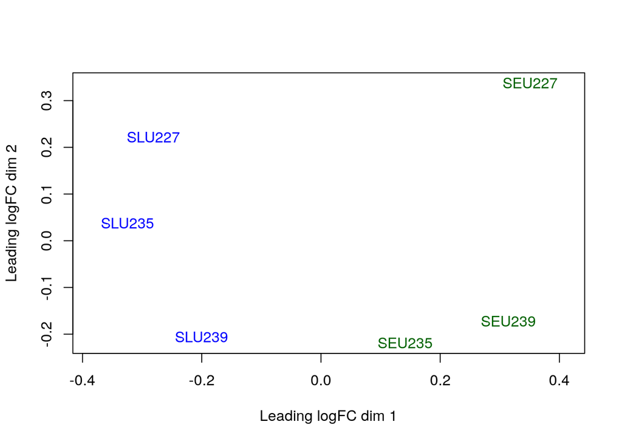

```r
plotMDS(d, labels=rownames(samples),
  col = c("darkgreen","blue")[factor(samples$condition)])
```

##### Estimate common and tagwise dispersion

```r
model_design <- model.matrix(~samples$condition + samples$cell)
d <- estimateDisp(d, model_design)
```

##### BCV plot

Dispersion is a measure of how much variation there is in samples. This plot seems not right, the number of genes is to less. Possibly, it caused by the scalar, most genes gather together.

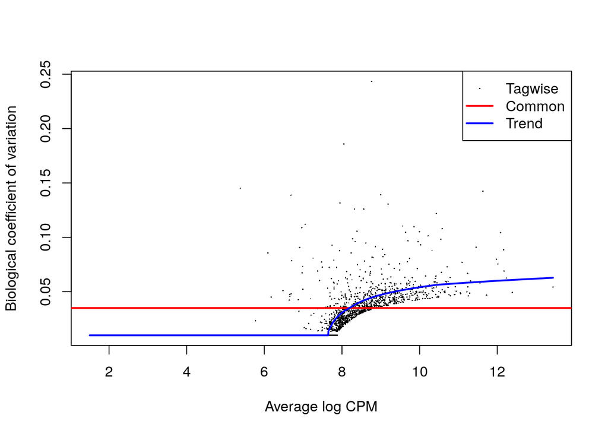

```r
plotBCV(d,col.tagwise = "black",col.common = "red")
```

##### Mean-variance relationship

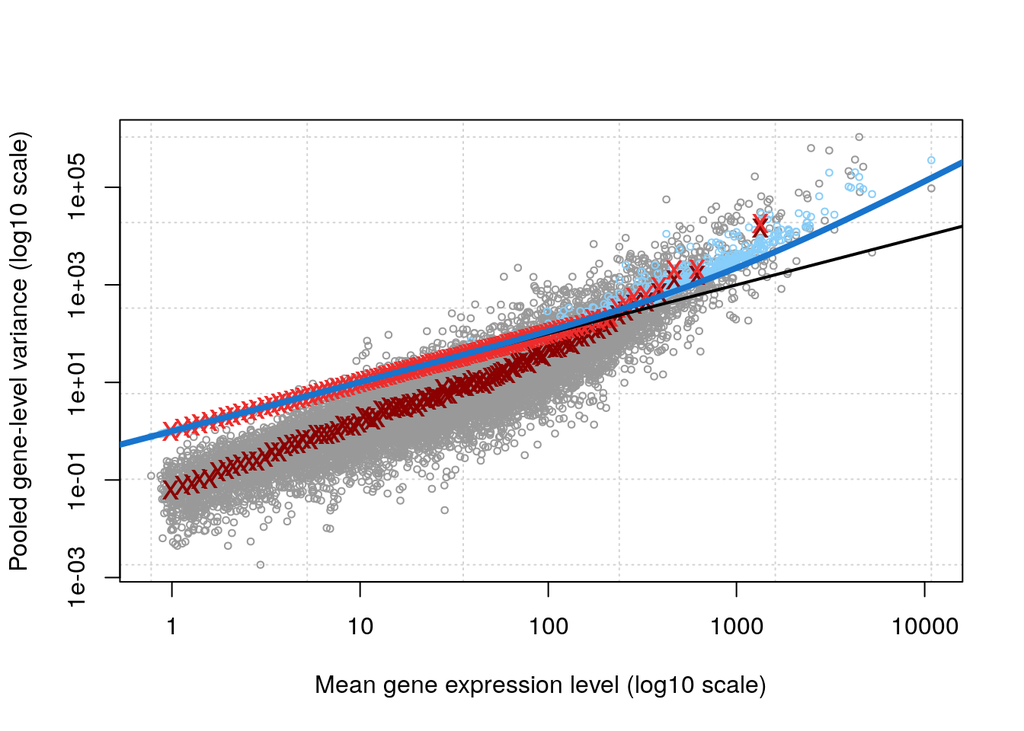

```r
plotMeanVar(d, show.raw.vars = TRUE, show.tagwise.vars=TRUE,
            show.ave.raw.vars = TRUE,
            NBline=TRUE,
            show.binned.common.disp.vars = TRUE)
```

#### Questions:

- What are the control and test conditions of the dataset?
  - Control group is Human STAT1-deficient fibroblasts stably expressing empty control vector in biological triplicate.
  - Test group is Human STAT1-deficient fibroblasts stably expressing LY6E in biological triplicate.
- Why is the dataset of interest to you?
  - This dataset aims to explore whether LY6E enhance viral infectivity or not. Which is helpful for us to understand the mechanism of antiviral immunity. Especially, 2019-nCoV is raging the world now, I want to know more about the viral infection.
- Were there expression values that were not unique for specific genes? How did you handle these?
  - No, There is no duplicate
- Were there expression values that could not be mapped to current HUGO symbols?
  - No, The data already has column called GENE_NAME which is HUGO symbols, Then, I used https://www.genenames.org/tools/multi-symbol-checker/ to check the symbols, all mapped.
- How many outliers were removed?
  - The origin data has 19410 genes, filtered data has 11433 genes, 7977 genes have been removed.
- How did you handle replicates?
  - Divided the 6 samples to 2 groups(empty control, test), each group has 3 replicates. Every sample looks good, so I kept all of them.
- What is the final coverage of your dataset?
  - The final coverage is 11433 genes.

# Reference

1. https://ropenscilabs.github.io/r-docker-tutorial/02-Launching-Docker.html
2. https://stackoverflow.com/questions/9756360/split-character-data-into-numbers-and-letters
3. Mar KB, Rinkenberger NR, Boys IN, Eitson JL et al. LY6E mediates an evolutionarily conserved enhancement of virus infection by targeting a late entry step. Nat Commun 2018 Sep 6;9(1):3603. PMID: 30190477